# RETRASCORE: torax aislado frente a torax con otra lesion

2026-09-21

# Objetivo

Crear dos grupos de pacientes con lesion toracica grave y repetir la estructura de la Tabla 2 del articulo RETRASCORE, mostrando en porcentaje las veinte variables candidatas:

1. **Torax solo:** `mais_torax = 1` y las otras cinco regiones MAIS son 0.
2. **Torax + otra lesion:** `mais_torax = 1` y al menos otra region MAIS es 1.

En el archivo preprocesado, una variable `mais_*` vale 1 cuando el AIS maximo de esa region es mayor o igual a 3. Esta definicion coincide con la nota de la Tabla 2 del articulo: MAIS = AIS >=3.

# Carga de datos

```r
archivo_cohorte <- "C:/Users/user/OneDrive - udl.cat/Desktop/RETRASCORE_VALIDATION/cohorte_retrascore.rds"

if (!file.exists(archivo_cohorte)) {
  stop(
    "cohorte_retrascore.rds was not found. ",
    "Run retrascore_validation_preprocessing.Rmd first."
  )
}

cohorte_retrascore <- readRDS(archivo_cohorte)

columnas_mais <- c(
  "mais_cabeza", "mais_torax", "mais_abdomen",
  "mais_ext_superior", "mais_ext_inferior", "mais_externo"
)

if (!all(columnas_mais %in% names(cohorte_retrascore))) {
  stop("Faltan una o mas columnas MAIS en cohorte_retrascore.rds.")
}
```

# Creacion de los grupos

No se eliminan registros de la cohorte original. Se crea un nuevo data frame que contiene pacientes con `mais_torax = 1` y las seis variables MAIS disponibles. No se imputan valores ausentes.

```r
otras_regiones_mais <- setdiff(columnas_mais, "mais_torax")
mais_completo <- complete.cases(cohorte_retrascore[columnas_mais])

cohorte_torax <- cohorte_retrascore[
  mais_completo & cohorte_retrascore$mais_torax == 1,
]

cohorte_torax$n_otras_regiones_mais <- rowSums(
  cohorte_torax[otras_regiones_mais] == 1
)

cohorte_torax$grupo_torax <- factor(
  ifelse(
    cohorte_torax$n_otras_regiones_mais == 0,
    "Torax solo",
    "Torax + otra lesion"
  ),
  levels = c("Torax solo", "Torax + otra lesion")
)

recuento_grupos <- data.frame(
  grupo = levels(cohorte_torax$grupo_torax),
  n = as.integer(table(cohorte_torax$grupo_torax)),
  porcentaje = round(
    100 * as.numeric(prop.table(table(cohorte_torax$grupo_torax))),
    1
  )
)

knitr::kable(recuento_grupos, row.names = FALSE)
```

| grupo | n | porcentaje |
| --- | --- | --- |
| Torax solo | 3131 | 43.9 |
| Torax + otra lesion | 3998 | 56.1 |

# Tabla 2 por patron de lesion toracica

Los porcentajes se calculan entre los pacientes con dato disponible para cada variable. El valor p compara los dos grupos mediante chi-cuadrado; se utiliza la prueba exacta de Fisher cuando alguna frecuencia esperada es menor de 5. Las filas MAIS que definen los grupos no se someten a contraste estadistico.

Tabla 2. Variables RETRASCORE segun patron de lesion toracica. Valores expresados como porcentajes.

| Variable | Torax solo (N=3131), % | Torax + otra lesion (N=3998), % | Valor p |
| --- | --- | --- | --- |
| Edad (grupos) |  |  | <0.001 |
| <50 | 43.6 | 53.2 |  |
| 50-65 | 32.8 | 27.0 |  |
| 66-75 | 13.9 | 11.3 |  |
| >75 | 9.8 | 8.4 |  |
| Sexo masculino | 84.8 | 77.0 | <0.001 |
| PRECOAG | 11.7 | 8.6 | <0.001 |
| Atencion prehospitalaria medica | 72.6 | 90.8 | <0.001 |
| Intubacion prehospitalaria | 7.0 | 35.6 | <0.001 |
| Mecanismo de alto riesgo | 26.2 | 30.4 | <0.001 |
| Mecanismo penetrante | 8.0 | 3.9 | <0.001 |
| Pupilas |  |  | <0.001 |
| Normales | 98.6 | 86.6 |  |
| Midriasis unilateral | 0.7 | 7.6 |  |
| Midriasis bilateral | 0.7 | 5.8 |  |
| GCS <=8 | 4.6 | 30.7 | <0.001 |
| MAIS cabeza | 0.0 | 51.3 | - |
| MAIS torax | 100.0 | 100.0 | - |
| MAIS abdomen | 0.0 | 35.7 | - |
| MAIS extremidad superior | 0.0 | 4.8 | - |
| MAIS extremidad inferior | 0.0 | 40.8 | - |
| MAIS externo | 0.0 | 0.5 | - |
| Fallo hemodinamico | 11.0 | 39.0 | <0.001 |
| Fallo respiratorio | 11.2 | 21.7 | <0.001 |
| Coagulopatia | 7.4 | 29.2 | <0.001 |
| Ventilacion mecanica | 21.0 | 59.0 | <0.001 |
| Hemorragia masiva | 2.6 | 12.5 | <0.001 |

PRECOAG: tratamiento previo con antiagregantes o anticoagulantes. GCS: Glasgow Coma Score. MAIS: lesion regional con AIS mayor o igual a 3. Los guiones de las filas MAIS indican que no se calcula un valor p porque esas variables forman parte de la definicion de los grupos.

# Tabla 2: torax, extremidad superior y resto de lesiones

Se repite la Tabla 2 conservando tres grupos mutuamente excluyentes:

1. **Torax solo:** no existe otra region con MAIS >=3.
2. **Torax + extremidad superior:** la extremidad superior es la unica region adicional con MAIS >=3.
3. **Resto de lesiones:** los demas patrones con MAIS toracico >=3, incluida la afectacion de extremidad superior cuando se acompana de otra region.

```r
cohorte_torax$grupo_torax_extremidad <- factor(
  ifelse(
    cohorte_torax$n_otras_regiones_mais == 0,
    "Torax solo",
    ifelse(
      cohorte_torax$n_otras_regiones_mais == 1 &
        cohorte_torax$mais_ext_superior == 1,
      "Torax + extremidad superior",
      "Resto de lesiones"
    )
  ),
  levels = c(
    "Torax solo",
    "Torax + extremidad superior",
    "Resto de lesiones"
  )
)

recuento_grupos_extremidad <- data.frame(
  grupo = levels(cohorte_torax$grupo_torax_extremidad),
  n = as.integer(table(cohorte_torax$grupo_torax_extremidad)),
  porcentaje = round(
    100 * as.numeric(
      prop.table(table(cohorte_torax$grupo_torax_extremidad))
    ),
    1
  )
)

knitr::kable(recuento_grupos_extremidad, row.names = FALSE)
```

Tabla 2. Variables RETRASCORE: torax solo, torax con extremidad superior y resto de lesiones. Valores expresados como porcentajes.

| grupo | n | porcentaje |
| --- | --- | --- |
| Torax solo | 3131 | 43.9 |
| Torax + extremidad superior | 19 | 0.3 |
| Resto de lesiones | 3979 | 55.8 |

| Variable | Torax solo (N=3131), % | Torax + extremidad superior (N=19), % | Resto de lesiones (N=3979), % | Valor p |
| --- | --- | --- | --- | --- |
| Edad (grupos) |  |  |  | <0.001 |
| <50 | 43.6 | 89.5 | 53.1 |  |
| 50-65 | 32.8 | 5.3 | 27.1 |  |
| 66-75 | 13.9 | 0.0 | 11.4 |  |
| >75 | 9.8 | 5.3 | 8.4 |  |
| Sexo masculino | 84.8 | 78.9 | 77.0 | <0.001 |
| PRECOAG | 11.7 | 0.0 | 8.6 | <0.001 |
| Atencion prehospitalaria medica | 72.6 | 94.7 | 90.8 | <0.001 |
| Intubacion prehospitalaria | 7.0 | 47.4 | 35.6 | <0.001 |
| Mecanismo de alto riesgo | 26.2 | 26.3 | 30.4 | <0.001 |
| Mecanismo penetrante | 8.0 | 5.3 | 3.9 | <0.001 |
| Pupilas |  |  |  | <0.001 |
| Normales | 98.6 | 89.5 | 86.5 |  |
| Midriasis unilateral | 0.7 | 10.5 | 7.6 |  |
| Midriasis bilateral | 0.7 | 0.0 | 5.8 |  |
| GCS <=8 | 4.6 | 17.6 | 30.8 | <0.001 |
| MAIS cabeza | 0.0 | 0.0 | 51.6 | - |
| MAIS torax | 100.0 | 100.0 | 100.0 | - |
| MAIS abdomen | 0.0 | 0.0 | 35.9 | - |
| MAIS extremidad superior | 0.0 | 100.0 | 4.3 | - |
| MAIS extremidad inferior | 0.0 | 0.0 | 41.0 | - |
| MAIS externo | 0.0 | 0.0 | 0.5 | - |
| Fallo hemodinamico | 11.0 | 26.3 | 39.0 | <0.001 |
| Fallo respiratorio | 11.2 | 15.8 | 21.7 | <0.001 |
| Coagulopatia | 7.4 | 0.0 | 29.3 | <0.001 |
| Ventilacion mecanica | 21.0 | 57.9 | 59.0 | <0.001 |
| Hemorragia masiva | 2.6 | 0.0 | 12.6 | <0.001 |
| Mortalidad a 30 dias | 3.7 | 0.0 | 16.9 | <0.001 |

El valor p es el contraste global entre los tres grupos. Los porcentajes se calculan entre los pacientes con dato disponible para cada variable. Las filas MAIS no se contrastan porque se utilizan para definir los grupos.

# Valores ausentes

Esta tabla permite comprobar los denominadores que cambian por datos ausentes.

| variable | Torax solo | Torax + otra lesion |
| --- | --- | --- |
| edad_categoria | 21 | 36 |
| atencion_prehospitalaria_medica | 139 | 114 |
| pupilas | 6 | 11 |
| gcs_menor_igual_8 | 232 | 208 |
| fallo_hemodinamico | 4 | 1 |
| fallo_respiratorio | 4 | 1 |
| coagulopatia_24h | 4 | 1 |
| hemorragia_masiva | 4 | 1 |

# Fuente

La seleccion y el orden de las variables reproducen la Tabla 2 de `s13054-021-03845-6.pdf`. La tabla original compara supervivientes y no supervivientes; esta version sustituye esas columnas por los dos patrones de lesion toracica definidos mediante las variables MAIS.

# Clustering exploratorio

El clustering se realiza sin las variables MAIS utilizadas para crear `grupo_torax` y sin variables de resultado. De esta forma, los grupos anatomicos no se incorporan de manera circular y la mortalidad puede utilizarse despues para describir el pronostico de los clusters.

Se incluyen las variables clinicas de la Tabla 2 restantes. Como son binarias o categoricas, se construyen indicadores y se aplica CLARA con distancia Manhattan. Los indicadores de edad y pupilas se ponderan para que cada variable original tenga un peso maximo equivalente a una variable binaria.

```r
variables_cluster <- c(
  "edad_categoria", "genero_masculino", "precoag",
  "atencion_prehospitalaria_medica", "iot_prehospitalaria",
  "mecanismo_alto_riesgo", "trauma_penetrante", "pupilas",
  "gcs_menor_igual_8", "fallo_hemodinamico", "fallo_respiratorio",
  "coagulopatia_24h", "ventilacion_mecanica", "hemorragia_masiva"
)

casos_cluster <- complete.cases(cohorte_torax[variables_cluster])
datos_cluster <- cohorte_torax[casos_cluster, ]

binarias_cluster <- setdiff(
  variables_cluster,
  c("edad_categoria", "pupilas")
)

matriz_binarias <- as.matrix(datos_cluster[binarias_cluster])
matriz_edad <- model.matrix(
  ~ edad_categoria - 1,
  data = data.frame(edad_categoria = datos_cluster$edad_categoria)
) * 0.5
matriz_pupilas <- model.matrix(
  ~ pupilas - 1,
  data = data.frame(pupilas = datos_cluster$pupilas)
) * 0.5

matriz_cluster <- cbind(
  matriz_binarias,
  matriz_edad,
  matriz_pupilas
)
storage.mode(matriz_cluster) <- "double"

flujo_cluster <- data.frame(
  etapa = c(
    "Pacientes con MAIS toracico >=3",
    "Casos completos para clustering",
    "Excluidos por datos ausentes"
  ),
  n = c(
    nrow(cohorte_torax),
    nrow(datos_cluster),
    sum(!casos_cluster)
  )
)

knitr::kable(flujo_cluster, row.names = FALSE)
```

| etapa | n |
| --- | --- |
| Pacientes con MAIS toracico >=3 | 7129 |
| Casos completos para clustering | 6412 |
| Excluidos por datos ausentes | 717 |

## Seleccion del numero de clusters

Se comparan soluciones de 2 a 6 clusters mediante el ancho silhouette medio. Un valor mayor indica mejor separacion interna. Esta seleccion es exploratoria y no presupone que deban existir exactamente dos clusters.

```r
if (!requireNamespace("cluster", quietly = TRUE)) {
  stop("El paquete cluster es necesario para ejecutar este analisis.")
}

set.seed(20260921)
valores_k <- 2:6

modelos_k <- lapply(valores_k, function(k) {
  cluster::clara(
    matriz_cluster,
    k = k,
    metric = "manhattan",
    samples = 50,
    sampsize = min(1000, nrow(matriz_cluster)),
    rngR = TRUE,
    pamLike = TRUE
  )
})

silhouette_medio <- vapply(
  modelos_k,
  function(modelo) modelo$silinfo$avg.width,
  numeric(1)
)

k_optimo <- valores_k[which.max(silhouette_medio)]
modelo_optimo <- modelos_k[[which.max(silhouette_medio)]]

tabla_seleccion_k <- data.frame(
  clusters = valores_k,
  silhouette_medio = round(silhouette_medio, 3),
  seleccionado = ifelse(valores_k == k_optimo, "Si", "")
)

knitr::kable(tabla_seleccion_k, row.names = FALSE)
```

| clusters | silhouette_medio | seleccionado |
| --- | --- | --- |
| 2 | 0.415 | Si |
| 3 | 0.213 |  |
| 4 | 0.206 |  |
| 5 | 0.222 |  |
| 6 | 0.227 |  |

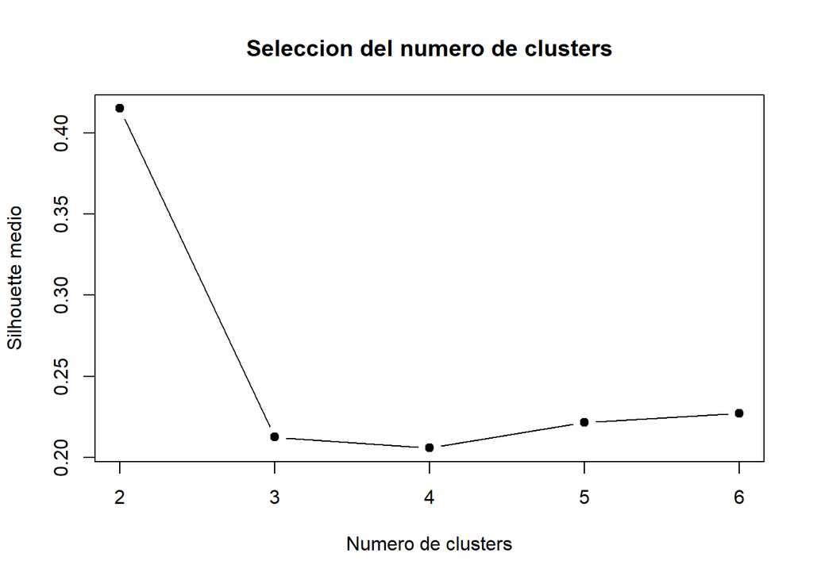

```r
plot(
  valores_k,
  silhouette_medio,
  type = "b",
  pch = 19,
  xlab = "Numero de clusters",
  ylab = "Silhouette medio",
  main = "Seleccion del numero de clusters"
)
```

## Estabilidad de la solucion seleccionada

Se repite CLARA cinco veces con semillas diferentes. La estabilidad se resume mediante el indice de Rand ajustado (ARI), que vale 1 cuando dos particiones coinciden completamente y se aproxima a 0 cuando su coincidencia es aleatoria.

```r
indice_rand_ajustado <- function(clase_a, clase_b) {
  tabla <- table(clase_a, clase_b)
  combinaciones_2 <- function(x) x * (x - 1) / 2

  acuerdo <- sum(combinaciones_2(tabla))
  suma_filas <- sum(combinaciones_2(rowSums(tabla)))
  suma_columnas <- sum(combinaciones_2(colSums(tabla)))
  total <- combinaciones_2(sum(tabla))
  esperado <- suma_filas * suma_columnas / total
  maximo <- (suma_filas + suma_columnas) / 2

  if (maximo == esperado) return(NA_real_)
  (acuerdo - esperado) / (maximo - esperado)
}

semillas_estabilidad <- 20260922:20260926
particiones_estabilidad <- lapply(semillas_estabilidad, function(semilla) {
  set.seed(semilla)
  cluster::clara(
    matriz_cluster,
    k = k_optimo,
    metric = "manhattan",
    samples = 50,
    sampsize = min(1000, nrow(matriz_cluster)),
    rngR = TRUE,
    pamLike = TRUE
  )$clustering
})

ari_estabilidad <- vapply(
  particiones_estabilidad[-1],
  function(particion) {
    indice_rand_ajustado(particiones_estabilidad[[1]], particion)
  },
  numeric(1)
)

tabla_estabilidad <- data.frame(
  comparacion = paste0("Repeticion 1 frente a ", 2:5),
  ARI = round(ari_estabilidad, 3)
)

knitr::kable(tabla_estabilidad, row.names = FALSE)
```

| comparacion | ARI |
| --- | --- |
| Repeticion 1 frente a 2 | 1 |
| Repeticion 1 frente a 3 | 1 |
| Repeticion 1 frente a 4 | 1 |
| Repeticion 1 frente a 5 | 1 |

## Solucion de dos clusters y grupos anatomicos

Aunque el numero optimo se selecciona sin imponerlo, se conserva una solucion de dos clusters para compararla directamente con `Torax solo` y `Torax + otra lesion`. La tabla presenta porcentajes por fila.

```r
modelo_k2 <- modelos_k[[which(valores_k == 2)]]
datos_cluster$cluster_2 <- factor(modelo_k2$clustering)

tabla_cluster_grupo <- table(
  datos_cluster$grupo_torax,
  datos_cluster$cluster_2
)

tabla_cluster_grupo_pct <- round(
  100 * prop.table(tabla_cluster_grupo, margin = 1),
  1
)

prueba_asociacion <- chisq.test(tabla_cluster_grupo, correct = FALSE)
cramer_v <- sqrt(
  as.numeric(prueba_asociacion$statistic) /
    (sum(tabla_cluster_grupo) *
      min(nrow(tabla_cluster_grupo) - 1, ncol(tabla_cluster_grupo) - 1))
)

ari_grupo_cluster <- indice_rand_ajustado(
  datos_cluster$grupo_torax,
  datos_cluster$cluster_2
)

knitr::kable(
  as.data.frame.matrix(tabla_cluster_grupo_pct),
  row.names = TRUE,
  caption = "Distribucion de los clusters dentro de cada grupo anatomico (%)"
)
```

Distribucion de los clusters dentro de cada grupo anatomico (%)

|  | 1 | 2 |
| --- | --- | --- |
| Torax solo | 93.1 | 6.9 |
| Torax + otra lesion | 59.2 | 40.8 |

```r
resumen_asociacion <- data.frame(
  medida = c("Valor p chi-cuadrado", "V de Cramer", "ARI"),
  valor = c(
    formatear_p(prueba_asociacion$p.value),
    sprintf("%.3f", cramer_v),
    sprintf("%.3f", ari_grupo_cluster)
  )
)

knitr::kable(resumen_asociacion, row.names = FALSE)
```

| medida | valor |
| --- | --- |
| Valor p chi-cuadrado | <0.001 |
| V de Cramer | 0.381 |
| ARI | 0.066 |

## Tabla 2 por cluster

Se repite la estructura completa de la Tabla 2 para comparar la solucion de dos clusters. Los porcentajes se calculan entre los pacientes con dato disponible para cada variable. La mortalidad se presenta como una fila adicional y no intervino en la creacion de los clusters.

Tabla 2. Variables RETRASCORE segun la solucion de dos clusters. Valores expresados como porcentajes.

| Variable | Cluster 1 (N=4730), % | Cluster 2 (N=1682), % | Valor p |
| --- | --- | --- | --- |
| Edad (grupos) |  |  | <0.001 |
| <50 | 47.0 | 55.8 |  |
| 50-65 | 30.7 | 25.9 |  |
| 66-75 | 12.7 | 11.0 |  |
| >75 | 9.6 | 7.3 |  |
| Sexo masculino | 80.6 | 78.6 | 0.079 |
| PRECOAG | 10.1 | 9.0 | 0.181 |
| Atencion prehospitalaria medica | 79.1 | 97.3 | <0.001 |
| Intubacion prehospitalaria | 5.0 | 78.0 | <0.001 |
| Mecanismo de alto riesgo | 26.3 | 33.3 | <0.001 |
| Mecanismo penetrante | 6.2 | 4.8 | 0.026 |
| Pupilas |  |  | <0.001 |
| Normales | 98.5 | 72.1 |  |
| Midriasis unilateral | 1.1 | 15.3 |  |
| Midriasis bilateral | 0.4 | 12.6 |  |
| GCS <=8 | 2.1 | 69.6 | <0.001 |
| MAIS cabeza | 18.4 | 61.6 | <0.001 |
| MAIS torax | 100.0 | 100.0 | - |
| MAIS abdomen | 16.7 | 29.5 | <0.001 |
| MAIS extremidad superior | 1.5 | 6.2 | <0.001 |
| MAIS extremidad inferior | 18.1 | 38.0 | <0.001 |
| MAIS externo | 0.1 | 0.5 | 0.018 |
| Fallo hemodinamico | 10.2 | 75.4 | <0.001 |
| Fallo respiratorio | 11.0 | 35.0 | <0.001 |
| Coagulopatia | 7.8 | 54.6 | <0.001 |
| Ventilacion mecanica | 25.8 | 93.9 | <0.001 |
| Hemorragia masiva | 2.5 | 25.0 | <0.001 |
| Mortalidad a 30 dias | 3.5 | 32.8 | <0.001 |

## Perfil clinico de los dos clusters

Los porcentajes siguientes describen cada cluster usando las mismas variables que entraron en el algoritmo.

Perfil clinico de la solucion de dos clusters (%)

| Variable | Cluster 1 | Cluster 2 |
| --- | --- | --- |
| Edad <50 | 47.0 | 55.8 |
| Edad 50-65 | 30.7 | 25.9 |
| Edad 66-75 | 12.7 | 11.0 |
| Edad >75 | 9.6 | 7.3 |
| Sexo masculino | 80.6 | 78.6 |
| PRECOAG | 10.1 | 9.0 |
| Atencion prehospitalaria medica | 79.1 | 97.3 |
| Intubacion prehospitalaria | 5.0 | 78.0 |
| Mecanismo de alto riesgo | 26.3 | 33.3 |
| Mecanismo penetrante | 6.2 | 4.8 |
| Pupilas normales | 98.5 | 72.1 |
| Midriasis unilateral | 1.1 | 15.3 |
| Midriasis bilateral | 0.4 | 12.6 |
| GCS <=8 | 2.1 | 69.6 |
| Fallo hemodinamico | 10.2 | 75.4 |
| Fallo respiratorio | 11.0 | 35.0 |
| Coagulopatia | 7.8 | 54.6 |
| Ventilacion mecanica | 25.8 | 93.9 |
| Hemorragia masiva | 2.5 | 25.0 |

[figure not shown]

## Visualizacion de los pacientes

La proyeccion de componentes principales se usa solamente para visualizar la matriz de indicadores; no participa en la asignacion de clusters.

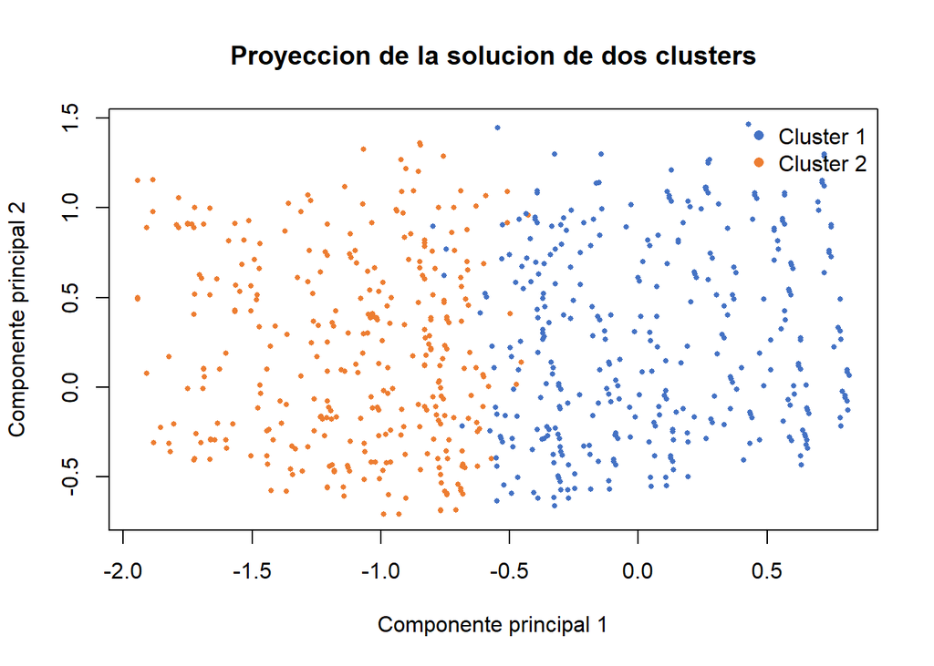

## Mortalidad posterior al clustering

La mortalidad no se utilizo para crear los clusters. Se presenta despues para describir si los perfiles identificados tienen diferente pronostico.

| cluster | n | mortalidad_30d_n | mortalidad_30d_denominador | mortalidad_30d_pct |
| --- | --- | --- | --- | --- |
| Cluster 1 | 4730 | 165 | 4730 | 3.5 |
| Cluster 2 | 1682 | 551 | 1679 | 32.8 |

El clustering es exploratorio. Una asociacion entre los clusters y los grupos anatomicos no implica que sean equivalentes ni demuestra causalidad. La interpretacion debe considerar el silhouette, la estabilidad, el perfil de variables y el tamano clinico de las diferencias.